# 2.Controls

Kate Bowie, PhD and Lisa Karstens, PhD

2025-03-07

# Purpose

This RMD is all about creating the ps object and evaluating controls. It includes: * Includes creating the ps object from the CSVs * Assigning disease to samples * Evaluating reads (abundance and length) * Examining positive and negative controls * Removing contamination

# Libraries

```r
library(phyloseq)
library(ggplot2)
library(plyr)
library(tidyverse)
library(patchwork)
library(kableExtra)
library(RColorBrewer)
library(speedyseq)
library(here)
library(microshades)
library(vegan)
library(seqinr)
library(gt)
library(ggpubr)
library(data.table)
library(dplyr)
options(dplyr.summarise.inform = FALSE)
```

# Load data

```r
asv_table <- fread(here("2024_code", "asv_table.csv")) #BL_EDIT -- fread can read this better, issues with original loading

tax_table <- read_csv(file = here("2024_code", "tax_table.csv"), col_names = TRUE)
```

```
## ──────────────────────────────────────────────────────── Delimiter: "," chr
## (8): ...1, Kingdom, Phylum, Class, Order, Family, Genus, Species
```

```r
meta <- read_csv(file = here("2024_code", "meta.csv"), col_names = TRUE)
```

```
## ──────────────────────────────────────────────────────── Delimiter: "," chr
## (8): sample_ID, patient_ID, fraction, replicate, replicate_ID, dnase, is... dbl
## (8): ...1, ...2, extraction_batch, orig_plate, SampleSums, age, PSA, BMI
```

### Formatting adjustments

```r
asv_table <- data.frame(asv_table)
rownames(asv_table) <- asv_table[,1]

asv_table <- asv_table %>%
  select(-"V1")
#  select(-"...1") # BL_EDIT - changed from ...1 to V1

asv_table <- as.matrix(asv_table)


tax_table <- data.frame(tax_table)
rownames(tax_table) <- tax_table[,1]

tax_table <- tax_table %>%
  select(-"...1")

tax_table <- as.matrix(tax_table)

meta <- data.frame(meta)
rownames(meta) <- meta$X

meta <- meta %>%
  select(-"...1", -"...2")
```

### Create ps object

```r
otu_data <- otu_table(asv_table, taxa_are_rows = FALSE)
sample_data <- sample_data(meta)
tax_data   <- tax_table(tax_table)

ps_orig <- phyloseq(otu_data, sample_data, tax_data)

tax_ps <- as.matrix(ps_orig@tax_table)

rm(asv_table, tax_table)
```

### Seperate mock community samples

```r
meta$patient_ID[meta$fraction == "mock_community"] <- paste0(meta$replicate[meta$fraction == "mock_community"], "_", meta$extraction_batch[meta$fraction == "mock_community"])

meta$extraction <- "NA"

meta$extraction[meta$fraction == "mock_community"] <- meta$extraction_batch[meta$fraction == "mock_community"]

sample_data(ps_orig) <- meta
```

### Combining samples

As noted previously, all samples were processed in triplicate. As blood is low microbial biomass, we thought the 200 µL samples would not adequately capture the composition. Therefore, the replicates for each sequencing sample were combined prior to rarefaction to represent one microbiome composition per fraction per individual.

```r
ps_df <- psmelt(ps_orig)

ps_df <- ps_df %>%
  group_by(fraction, patient_ID, dnase, OTU) %>%
  summarise(tot_abundance = sum(Abundance))


# create new sample names
ps_df <- ps_df %>%
  mutate(sam_names = paste0(fraction, "_", patient_ID, "_", dnase))
```

### Make combined OTU table

```r
otu_ps <- ps_df %>%
  select(sam_names, OTU, tot_abundance) %>%
  pivot_wider(names_from = OTU, values_from = tot_abundance, id_cols = sam_names) %>%
  data.frame()
rownames(otu_ps) <- otu_ps$sam_names
otu_ps <- otu_ps %>%
  select(-sam_names) %>%
  as.matrix()
```

### Adding back in meta data

```r
meta_combo <- meta %>%
  select(patient_ID, fraction, dnase, is.neg, PSA, BMI, age, extraction)

meta <- meta_combo %>%
  mutate(sam_names = paste0(fraction, "_", patient_ID, "_", dnase)) %>%
  unique()

rownames(meta) <- meta$sam_names
```

### Create combined ps object

```r
ps <- phyloseq(otu_table(otu_ps, taxa_are_rows = FALSE), tax_table(tax_ps), sample_data(meta))

rm(tax_ps, otu_ps, ps_df, meta_combo)

## Add disease

meta_ps <- meta %>%
mutate(disease = case_when(
patient_ID %in% c(1,8,10,14,15) ~ "low-grade",
patient_ID %in% c(4,5,9,11,12) ~ "high-grade",
patient_ID %in% c(2,3,6,13,16) ~ "screen-negative",
TRUE ~ patient_ID,
))

sample_data(ps) <- meta_ps
```

# Filtering by sequence quality

### Read length

First let’s take a look at the length. Full-length 16S rRNA gene should be around 1500 bp. We have a lot of short sequences that we aren’t confident in and will filter out.

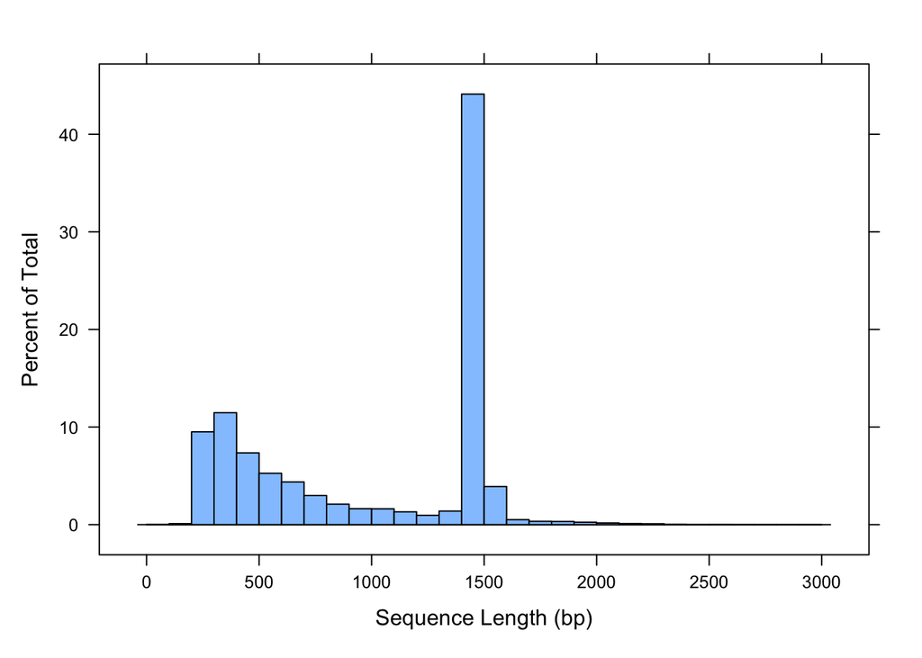

```r
histogram(nchar(taxa_names(ps)), breaks = 30, , xlab="Sequence Length (bp)")
```

### Sequences 1350 < x < 1600

As we’re focusing only on sequences we have full confidence in, we will continue our analyses with only sequences between 1350 and 1600 bp.

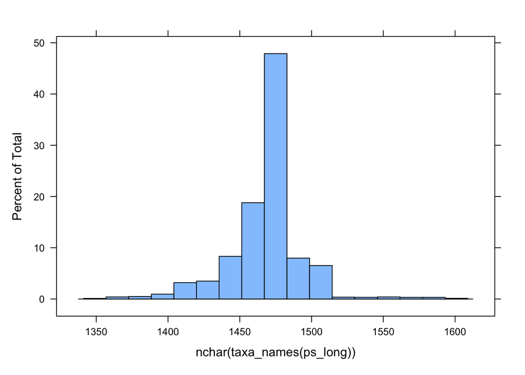

```r
taxa_to_keep <- data.frame(taxa_id = taxa_names(ps), seq_long = nchar(taxa_names(ps)) > 1350 & nchar(taxa_names(ps)) < 1600)

taxa_to_keep <- taxa_to_keep %>%
  filter(seq_long == TRUE)

ps_long <- subset_taxa(ps, taxa_names(ps) %in% taxa_to_keep$taxa_id)

# checking
histogram(nchar(taxa_names(ps_long)))
```

# Filtering to Family

We only want sequences that we have high confidence in, therefore we have decided to only use sequences that at least have resolution to the Family level. Before filtering, 48896 ASVs. Afterwards, 38,939

```r
ps <- ps_long %>%
  subset_taxa(., !(is.na(Family)))
```

# Sample reads overview

```r
sample_data(ps_long)$SampleSums <- sample_sums(ps_long)
meta <- data.frame(ps_long@sam_data)
```

## Reads

```r
# overall
meta %>%
  filter(dnase == "no" & fraction != "mock_community") %>%
  summarise(median_ss = median(SampleSums), avg_ss = mean(SampleSums), range_ss = range(SampleSums))
```

| median_ss | avg_ss | range_ss |
| --- | --- | --- |
| 341 | 392.85 | 14 |
| 341 | 392.85 | 1877 |

```r
table(meta$fraction, meta$dnase)
```

```
##
##                  neg no yes
##   BF               1 15  10
##   mock_community   0 20   0
##   plasma           1 15   2
##   RBC              1 15   7
##   WB               1 15   9
```

# Mock Community Summary

### Supplementary fig 1

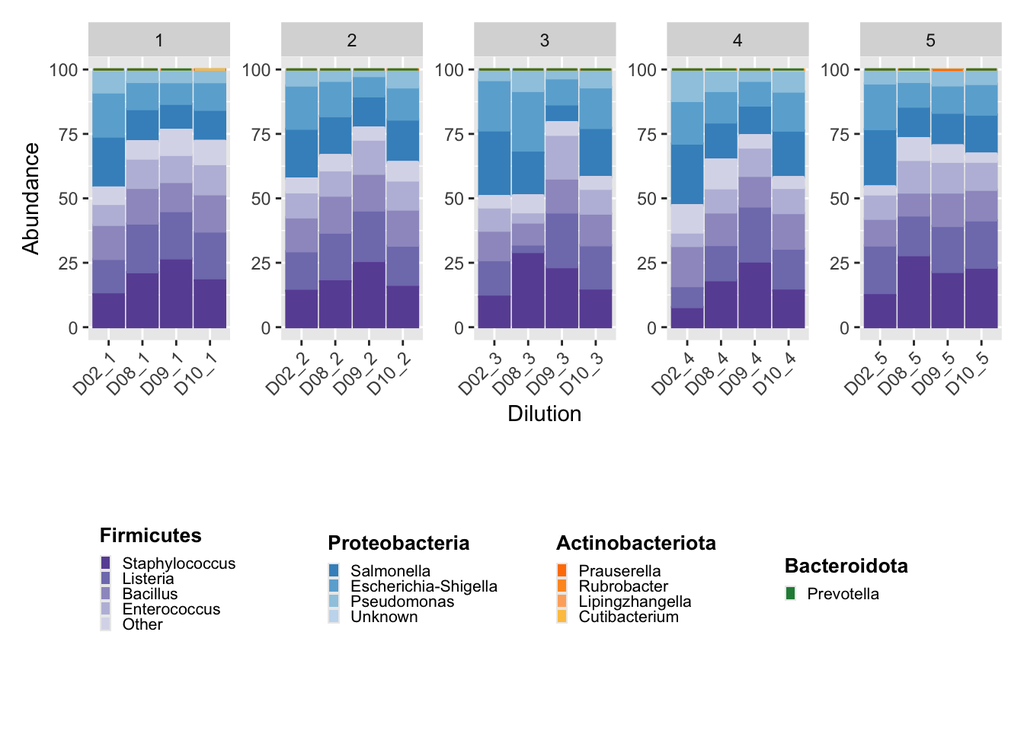

```r
# agglomerating at the genus level
ps_mc <- ps %>%
  subset_samples(., fraction == "mock_community") %>%
  tax_glom("Genus", NArm = FALSE)

ps_mc <- subset_taxa(ps_mc, taxa_sums(ps_mc) > 0) # 107 genera
ps_mc_rel <- transform_sample_counts(ps_mc, function(x) 100* x/sum(x))

sample_data(ps_mc)$SampleSums <- sample_sums(ps_mc)
meta_mc <- data.frame(ps_mc@sam_data)


# plotting
mc_rel_df <- ps_mc_rel %>% psmelt()

color_df <- create_color_dfs(mc_rel_df, group_level = "Phylum", subgroup_level = "Genus", selected_groups = c("Bacteroidota", "Actinobacteriota", "Proteobacteria", "Firmicutes"))


c_legend <-custom_legend(color_df$mdf, color_df$cdf, legend_orientation = "horizontal")


plot <- color_df$mdf %>%
  #filter(replicate_ID %in% c("D02", "D08", "D09", "D10")) %>%
  plot_microshades(., color_df$cdf, group_label = "Phylum-Genus", x = "patient_ID") +
  theme(legend.position = "none") +
  facet_wrap(~extraction, scales = "free", nrow = 1) + xlab("Dilution")

plot / c_legend
```

### By reads

```r
meta_mc %>%
  summarise(median_ss = median(SampleSums), avg_ss = mean(SampleSums), range_ss = range(SampleSums))
```

| median_ss | avg_ss | range_ss |
| --- | --- | --- |
| 4356.5 | 4225 | 96 |
| 4356.5 | 4225 | 7990 |

```r
# quantiles
meta_mc %>%
  summarize(iqr_ss = quantile(SampleSums, prob=c(.25,.5,.75), type=1))
```

| iqr_ss |
| --- |
| 2670 |
| 4301 |
| 5751 |

### By Taxa - Genus

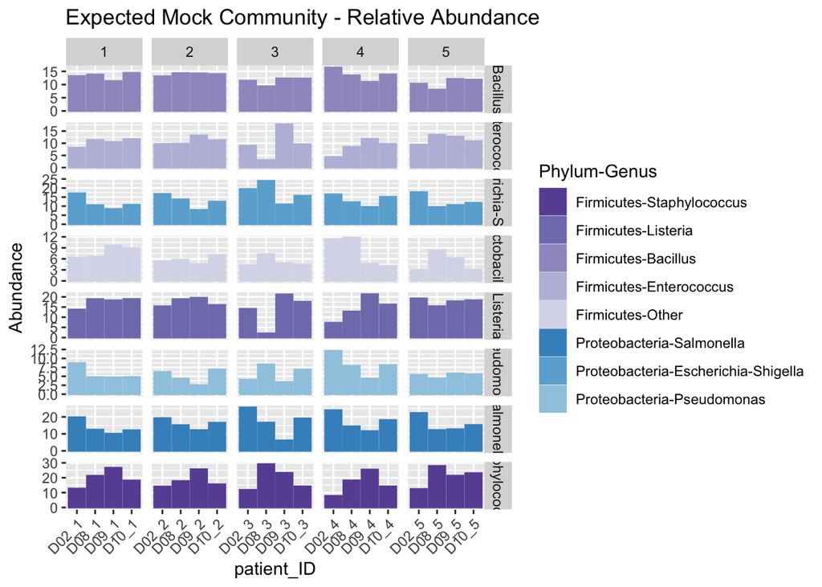

```r
exp_taxa <- c("Bacillus", "Enterococcus", "Escherichia-Shigella", "Lactobacillus", "Listeria", "Pseudomonas", "Salmonella", "Staphylococcus")


# Relative abundance
mc_mdf <- color_df$mdf %>%
  filter(Genus %in% exp_taxa) %>%
  mutate(extraction = as.factor(extraction))

plot_microshades(mc_mdf, color_df$cdf, group_label = "Phylum-Genus", x = "patient_ID") +
  facet_grid(Genus~extraction, scales = "free") +
  ggtitle("Expected Mock Community - Relative Abundance")
```

#### Unexpected taxa

```r
mc_mdf <- color_df$mdf %>%
  filter(!(Genus %in% exp_taxa)) %>%
  mutate(extraction = as.factor(extraction))

mc_mdf %>%
  summarise(med_abund = median(Abundance), avg_abund = mean(Abundance), range_abund = range(Abundance))
```

| med_abund | avg_abund | range_abund |
| --- | --- | --- |
| 0 | 0.0120334 | 0.0000000 |
| 0 | 0.0120334 | 0.3282455 |

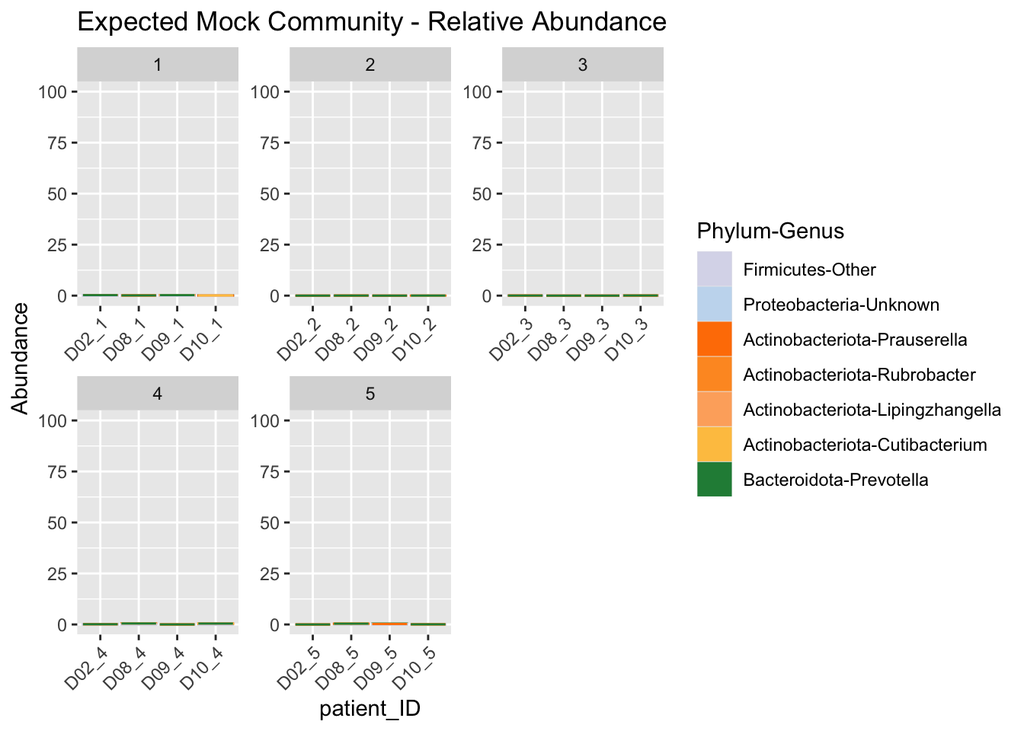

```r
plot_microshades(mc_mdf, color_df$cdf, group_label = "Phylum-Genus", x = "patient_ID") +
  facet_wrap(~extraction, scales = "free") +
  ggtitle("Expected Mock Community - Relative Abundance") +
  ylim(0,100)
```

### By Taxa - Species

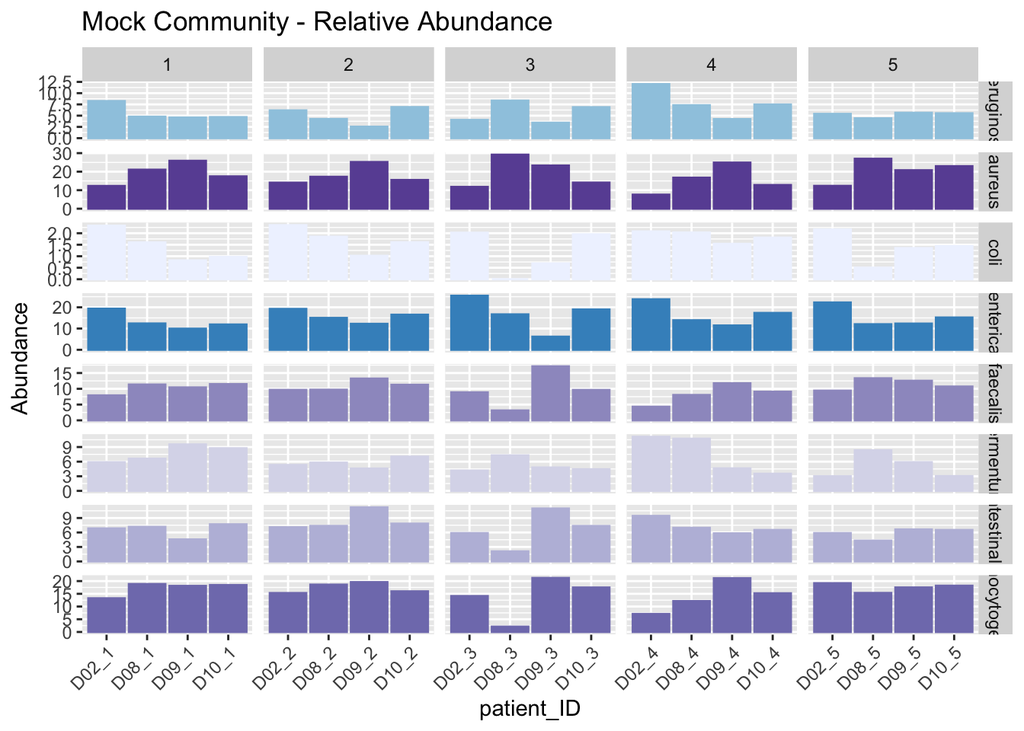

```r
exp_species <- c("aeruginosa", "coli", "enterica", "fermentum", "aureus", "monocytogenes", "subtilis", "faecalis", "intestinalis")


# agglomerating at the species level
ps_mc <- ps_long %>%
  subset_samples(., fraction == "mock_community") %>%
  tax_glom(., "Species", NArm = FALSE)

ps_mc <- subset_taxa(ps_mc, taxa_sums(ps_mc) > 0) # 91 Species
ps_mc_rel <- transform_sample_counts(ps_mc, function(x) 100* x/sum(x))

sample_data(ps_mc)$SampleSums <- sample_sums(ps_mc)
meta_mc <- data.frame(ps_mc@sam_data)

ps_mc_df <- ps_mc_rel %>% psmelt()

color_df <- create_color_dfs(ps_mc_df, group_level = "Phylum", subgroup_level = "Species", selected_groups = c("Bacteroidota", "Actinobacteriota", "Proteobacteria", "Firmicutes"))


mc_mdf <- color_df$mdf %>%
  filter(Species %in% exp_species)

### Only D2, D8-D10
mc_mdf <- color_df$mdf %>%
  filter(Species %in% exp_species) %>%
  mutate(extraction = as.factor(extraction))


plot_microshades(mc_mdf, color_df$cdf, group_label = "Phylum-Species", x = "patient_ID") +
  facet_grid(Species~extraction, scales = "free") +
  ggtitle("Mock Community - Relative Abundance") + theme(legend.position = "none")
```

### Clean up

```r
keep <- c("ps_orig", "meta", "ps")

rm(list=setdiff(ls(), keep))
```

# Negative controls

3 of my 23 negative controls failed sequencing. There is a negative for each sample type (plasma, RBC, BF, and WB). Similar to the blood fractions, all negatives for each fraction were run in triplicate. This means that each negative here is a combination of 3 samples, which is why the reads is higher than expected.

```r
ps_neg <- subset_samples(ps, is.neg == "yes")
ps_neg <- subset_taxa(ps_neg, taxa_sums(ps_neg) > 0)
sample_data(ps_neg)$SampleSums <- sample_sums(ps_neg)
meta_neg <- data.frame(ps_neg@sam_data)

meta_neg %>%
  summarise(avg_reads = mean(SampleSums), min_ss = min(SampleSums), max_ss = max(SampleSums))
```

| avg_reads | min_ss | max_ss |
| --- | --- | --- |
| 863.5 | 41 | 2950 |

### Top 5 genera

```r
# agglomerating at the genus level
ps_neg_g <- tax_glom(ps_neg, "Genus", NArm = FALSE)
ps_neg_g <- subset_taxa(ps_neg_g, taxa_sums(ps_neg_g) > 0) # 18 genera

sample_data(ps_neg_g)$SampleSums <- sample_sums(ps_neg_g)
meta_neg_g <- data.frame(ps_neg_g@sam_data)

# Calculate taxa sum of the selected samples
top5 <- head(sort(colSums(otu_table(ps_neg_g)), decreasing = TRUE), 5)

# Combine count and taxonomyTable
top5 <- cbind(as.data.frame(tax_table(ps_neg_g)[names(top5),]), Count = top5)
top5$Genus
```

```
## [1] "Bacillus"                    "Legionella"
## [3] "Prevotellaceae NK3B31 group" "Prauserella"
## [5] "Escherichia-Shigella"
```

### Clean-up

```r
keep <- c("ps_orig", "meta", "ps")

rm(list=setdiff(ls(), keep))
```

```r
ps_p <- ps %>%
  subset_samples(., fraction == "plasma")
ps_p <- subset_taxa(ps_p, taxa_sums(ps_p)>0)
ps_p_rel <- transform_sample_counts(ps_p, function(x) 100* x/sum(x))


ps_p_neg <- ps %>%
  subset_samples(., fraction == "plasma" & patient_ID == "neg")
ps_p_neg <- subset_taxa(ps_p_neg, taxa_sums(ps_p_neg)>0)

neg_taxa <- rownames(data.frame(ps_p_neg@tax_table))

# prepping microshades
ps_p_df <- psmelt(ps_p_rel)

color_df_asv <- create_color_dfs(ps_p_df, group_level = "Phylum", subgroup_level = "Genus", selected_groups = c("Bacteroidota", "Actinobacteriota", "Proteobacteria", "Firmicutes"))

# checking if same genera are in the samples
mc_mdf <- color_df_asv$mdf %>%
  filter(OTU %in% neg_taxa)

neg_p <- mc_mdf %>%
  filter(Abundance >0) %>%
    ggplot(., aes(x = sam_names, y = Abundance), fill = Genus) +
    scale_fill_brewer(palette = "Paired") +
  theme_bw() +
  scale_colour_manual(name = "",
                        values = color_df_asv$cdf$hex,
                        breaks = color_df_asv$cdf$group) +
    geom_bar(aes(color=Genus, fill=Genus), stat="identity", position="stack") +
    theme(axis.text.x = element_blank(), legend.position = "bottom", legend.title=element_blank(), legend.box.spacing = unit(0, "pt")) +
  ggtitle("Plasma") + xlab("")
```

### RBC

```r
ps_rbc <- ps %>%
  subset_samples(., fraction == "RBC")
ps_rbc <- subset_taxa(ps_rbc, taxa_sums(ps_rbc)>0)
ps_rbc_rel <- transform_sample_counts(ps_rbc, function(x) 100* x/sum(x))


ps_rbc_neg <- ps %>%
  subset_samples(., fraction == "RBC" & patient_ID == "neg")
ps_rbc_neg <- subset_taxa(ps_rbc_neg, taxa_sums(ps_rbc_neg)>0)

neg_taxa <- rownames(data.frame(ps_rbc_neg@tax_table))

# prepping microshades
ps_rbc_df <- psmelt(ps_rbc_rel)

color_df_asv <- create_color_dfs(ps_rbc_df, group_level = "Phylum", subgroup_level = "Genus", selected_groups = c("Bacteroidota", "Actinobacteriota", "Proteobacteria", "Firmicutes"))

# checking if same genera are in the samples
mc_mdf <- color_df_asv$mdf %>%
  filter(OTU %in% neg_taxa)

neg_rbc <- mc_mdf %>%
  filter(Abundance >0) %>%
    ggplot(., aes(x = sam_names, y = Abundance), fill = Genus) +
    scale_fill_brewer(palette = "Paired") +
  theme_bw() +
  scale_colour_manual(name = "",
                        values = color_df_asv$cdf$hex,
                        breaks = color_df_asv$cdf$group) +
    geom_bar(aes(color=Genus, fill=Genus), stat="identity", position="stack") +
    theme(axis.text.x = element_blank(), legend.position = "bottom", legend.title=element_blank(), legend.box.spacing = unit(0, "pt")) +
  ggtitle("Red Blood Cells") + xlab("")
```

### BF

```r
ps_bf <- ps %>%
  subset_samples(., fraction == "BF")
ps_bf <- subset_taxa(ps_bf, taxa_sums(ps_bf)>0)
ps_bf_rel <- transform_sample_counts(ps_bf, function(x) 100* x/sum(x))


ps_bf_neg <- ps %>%
  subset_samples(., fraction == "BF" & patient_ID == "neg")
ps_bf_neg <- subset_taxa(ps_bf_neg, taxa_sums(ps_bf_neg)>0)

neg_taxa <- rownames(data.frame(ps_bf_neg@tax_table))

# prepping microshades
ps_bf_df <- psmelt(ps_bf_rel)

color_df_asv <- create_color_dfs(ps_bf_df, group_level = "Phylum", subgroup_level = "Genus", selected_groups = c("Bacteroidota", "Actinobacteriota", "Proteobacteria", "Firmicutes"))

# checking if same genera are in the samples
mc_mdf <- color_df_asv$mdf %>%
  filter(OTU %in% neg_taxa)

neg_bf <- mc_mdf %>%
  filter(Abundance >0) %>%
    ggplot(., aes(x = sam_names, y = Abundance), fill = Genus) +
    scale_fill_brewer(palette = "Paired") +
  theme_bw() +
  scale_colour_manual(name = "",
                        values = color_df_asv$cdf$hex,
                        breaks = color_df_asv$cdf$group) +
    geom_bar(aes(color=Genus, fill=Genus), stat="identity", position="stack") +
    theme(axis.text.x = element_blank(), legend.position = "bottom", legend.title=element_blank(), legend.box.spacing = unit(0, "pt")) +
  ggtitle("Buffy Coat") + xlab("")
```

### WB

```r
ps_wb <- ps %>%
  subset_samples(., fraction == "WB")
ps_wb <- subset_taxa(ps_wb, taxa_sums(ps_wb)>0)
ps_wb_rel <- transform_sample_counts(ps_wb, function(x) 100* x/sum(x))


ps_wb_neg <- ps %>%
  subset_samples(., fraction == "WB" & patient_ID == "neg")
ps_wb_neg <- subset_taxa(ps_wb_neg, taxa_sums(ps_wb_neg)>0)

neg_taxa <- rownames(data.frame(ps_wb_neg@tax_table))

# prepping microshades
ps_wb_df <- psmelt(ps_wb_rel)

color_df_asv <- create_color_dfs(ps_wb_df, group_level = "Phylum", subgroup_level = "Genus", selected_groups = c("Bacteroidota", "Actinobacteriota", "Proteobacteria", "Firmicutes"))

# checking if same genera are in the samples
mc_mdf <- color_df_asv$mdf %>%
  filter(OTU %in% neg_taxa)

mc_mdf$Top_genus[mc_mdf$Genus == "Methylobacterium-Methylorubrum"] <- "Methylobacterium"


neg_wb <- mc_mdf %>%
  filter(Abundance >0) %>%
    ggplot(., aes(x = sam_names, y = Abundance), fill = Genus) +
    scale_fill_brewer(palette = "Paired") +
  theme_bw() +
  scale_colour_manual(name = "",
                        values = color_df_asv$cdf$hex,
                        breaks = color_df_asv$cdf$group) +
    geom_bar(aes(color=Genus, fill=Genus), stat="identity", position="stack") +
    theme(axis.text.x = element_blank(),
          legend.position = "bottom",
          legend.box.spacing = unit(0, "pt"),
          legend.title=element_blank(),
          legend.key.width = unit(1, "null")) +
  ggtitle("Whole Blood") +
  xlab("")
```